# Visualisation TP-2 : ”shiny"

rchailan

Octobre 2017

### Introduction

Nous avons vu dans le TP-1 comment réaliser efficacement des graphiques élégants et fonctionnels avec `ggplot2`. Au regard des technologies dont nous disposons, les explorations de données et les rendus d’analyses statistiques se veulent désormais dynamiques. Sous *R*, vous allez pouvoir construire des applications Web (dites WebApps) grâce à l’utilisation de [Shiny](https://shiny.rstudio.com).

Le développement de WebApps [Shiny](https://shiny.rstudio.com) est très bien détaillé sur internet. Il existe de nombreux [tutoriaux](https://shiny.rstudio.com/tutorial/) et [exemples](https://shiny.rstudio.com/gallery/) sur le site web, la communauté est très dynamique et l’évolution du code est continue.  
Il est facile d’intégrer les concepts de développement du package. Par conséquent, l’utilisation de [Shiny](https://shiny.rstudio.com) est bien souvent vu comme le choix par défaut lorsque une interface de rendu doit être développée rapidement, tout en restant performante et élégante.

Avant de commencer le TP, je vous invite à consulter deux exemples. Le [premier](http://www.dataseries.org/) est une WebApp qui permet d’explorer les séries chronologiques des variables reflétant l’économie de la Suisse, recueillies préalablement à partir de sources open data.  
Le [second](https://gallery.shinyapps.io/drinkr/) est une application plus attractive pour les étudiants : elle permet d’estimer la quantité d’alcool dans le sang d’une personne à partir de ses critères physiques, ainsi que les heures et les boissons que la personne a consommées.

**Pre-requis** : le TP est conçu pour être réalisé à l’aide de *RStudio* et du package `Shiny`. Avant de commencer, vérifier que ce dernier est bien installé dans sur votre machine.

### Exercice 1 : (Vanilla Shiny WebApp)

Dans ce premier exercice nous souhaitons créer une première application web (voir ci-après) à partir de l’IDE RStudio.

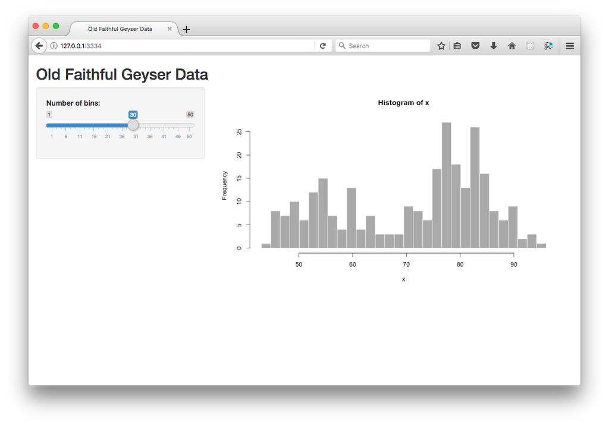

1. Ouvrez RStudio. À l’intérieur d’un nouveau projet, créez une nouvelle application *Shiny*. Nommez-la par exemple `Vanilla`. Vous pouvez choisir un unique fichier contenant la partie *UI* et la partie *SERVER*, soit choisir plusieurs fichiers. Pour plus de clareté dans votre code, il est conseillé d’utiliser les fichiers multiples. *Note : Par la suite nous supposons que l’étudiant a fait ce choix.*

[figure not shown]

2. Ouvrez le dossier créé par RStudio. Explorez les deux fichiers `ui.R` et `server.R`. Sans surprise, la logique et la description de l’interface utilisateur est contenue dans le fichier `ui.R`, alors que le *backend* est contenu dans le fichier `server.R`.  
   Dans `ui.R`, nous retrouvons
   - des éléments de structuration de la page web, inspirés du framework CSS/js [Bootstrap](http://getbootstrap.com/) comme par exemple `fluidPage()`, `sidebarLayout()` et `mainPanel()`;
   - des éléments graphiques statiques, comme par exemple le texte ou `titlePanel()`;
   - des éléments de saisie, comme `sliderInput()`;
   - des éléments de rendu dynamique, comme `plotOutput()`. Dans `server.R`, nous retrouvons la lecture/génération des données, et surtout les méthodes de construction d’éléments dynamiques qui sont ensuite rendus par l’interface.  
     **Les liasons entre `ui.R` et `server.R` se font à partir des clés d’identification, respectivement passées depuis et vers les objets `input` et `output`.**

Par exemple, pour récupérer le nombre de `bins` dans la partie `server.R` il faut utiliser `input$bins` puisque l’`input` est déclaré par

```r
# ui.R
sliderInput(inputId = "bins",
            ...)
```

Aussi, `plotOutput("distPlot")` affiche le contenu rendu par la fonction `renderPlot` et dont le résultat est stocké dans l’objet `output` avec

```r
# server.R
output$distPlot <- renderPlot(...)
```

3. Lancez directement l’application en cliquant sur le bouton `Run App` lorsque vous avez un de ces fichiers ouvert.
4. Observez quand faisant varier le nombre de “bins”, l’histogramme est alors bien rendu dynamiquement.

### Exercice 2 : (iris Shiny WebApp)

Dans cet exercice nous allons créer une interface afin d’explorer le jeu de données `iris` et les ajustement des modèles de régression de façon dynamique.

1. Reprenez le code de l’exercice 1 du TP-1. En vous inspirant de la WebApp `Vanilla`, affichez le graphique obtenu dans une nouvelle application nommée `iris`.

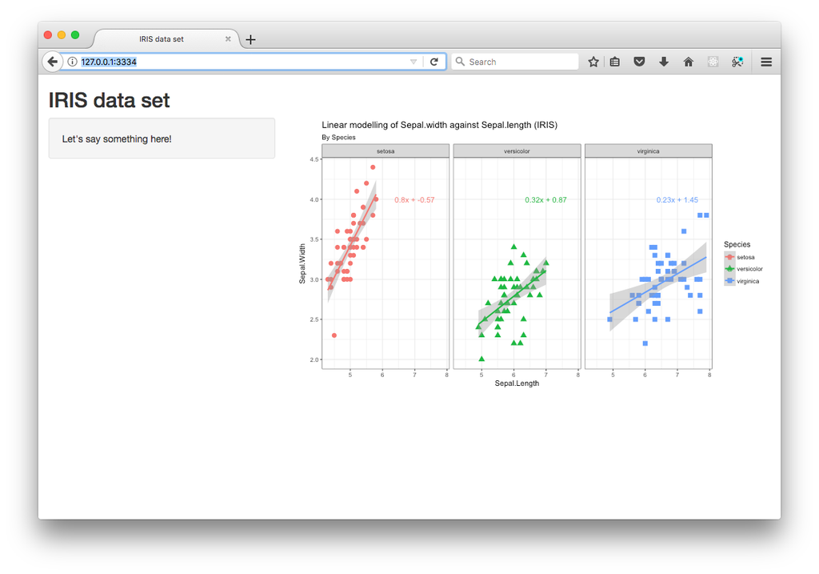

2. Filtrez les données à afficher en fonction de l’espèce. Pour se faire, commencez par ajouter dans le `sidebarPanel()` un composant `checkboxGroupInput()` qui permet d’afficher une liste de “checkboxes”.

```r
# example ui.R
checkboxGroupInput("variable", "Variables to show:",
                     c("Cylinders" = "cyl",
                       "Transmission" = "am",
                       "Gears" = "gear")),
```

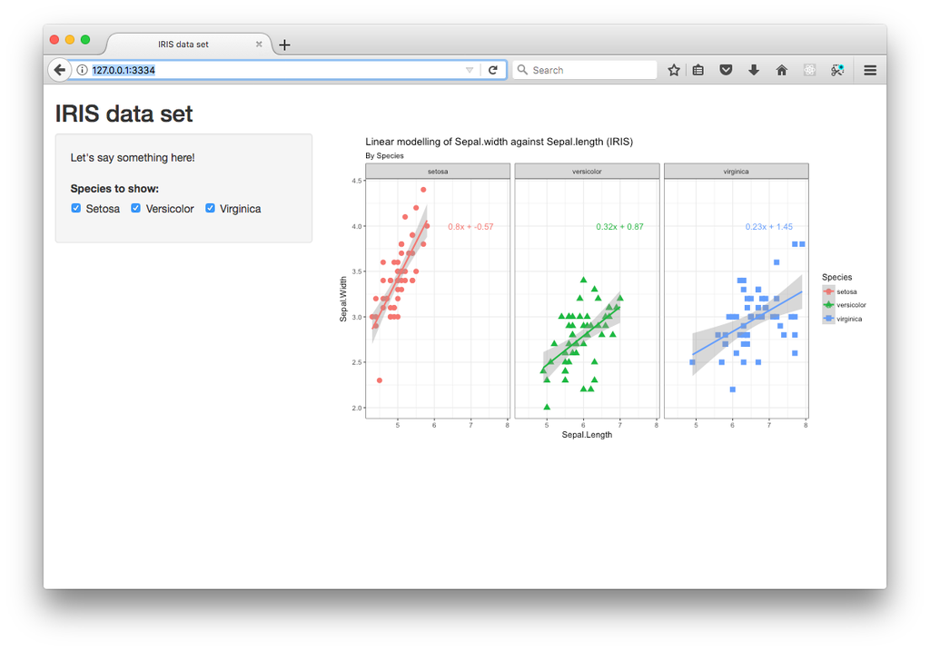

Ensuite, il faut prendre en compte cette information saisie dans l’interface utilisateur au niveau de la génération du graphe, c’est à dire dans le fichier `server.R`. Autrement dit, filtrez les `Species` du jeu de données de base par rapport à `input$votre_nom_Id_variable`.

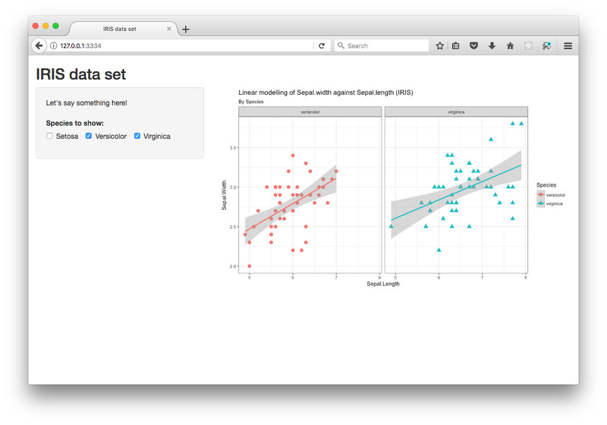

3. De manière équivalente, ajoutez une liste de `radioButtons()` pour contrôler le modèle de regression à utiliser dans votre graphe `ggplot`. Les méthodes de lissages disponibles sont `lm`, `glm`, `gam`, `loess`, `MASS:rlm`.

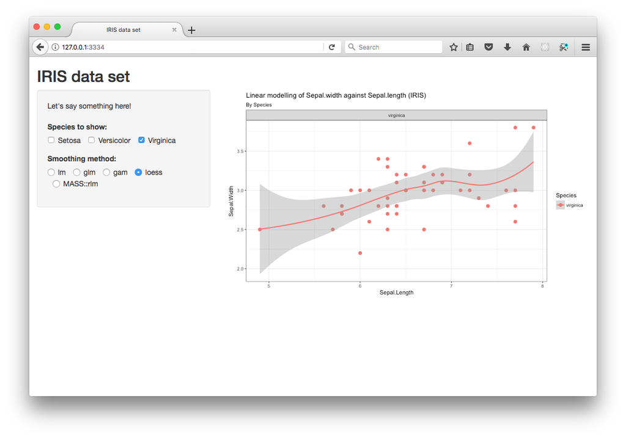

4. Enfin, restreignez les limites de votre graphique en abscisses et en ordonnées grâce à deux éléments `sliderInput()`.

```r
# example ui.R
sliderInput("x", "Sepal.length range:",
                   min = 4, max = 8,
                   value = c(4,8)),
```

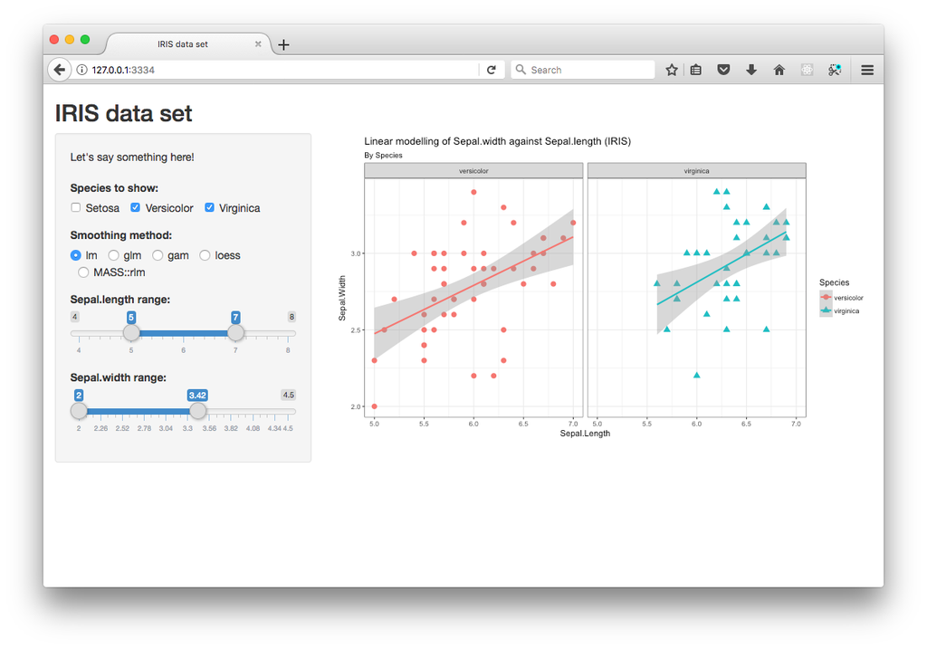

5. *[facultatif]* Continuez à explorer les divers éléments de contrôles en vous référant à la documentation. Quel(s) contrôle(s) pourriez vous rajouter pour ce graphique interactif ?

### Exercice 3 : (layouts)

Nous nous proposons d’explorer quelques éléments de mise en page *(layouts)* dans Shiny à travers cet exercice.

1. Reprenez l’application de l’exercice 2 et ajoutez un `tabsetPanel()` à votre page dans le mainPanel. Ajoutez ainsi trois graphiques du TP-1 ayant respectivement chacun un `tabpanel()`.

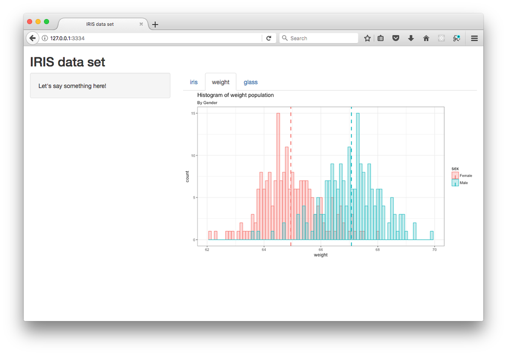

```r
# example
tabsetPanel(
    tabPanel("Plot", plotOutput("plot")),
    tabPanel("Summary", verbatimTextOutput("summary")),
    tabPanel("Table", tableOutput("table"))
  )
```

2. Remplacez le layout actuel par une `navbarPage()` pour avoir une barre de navigation. Déterminez un menu cohérent pour pouvoir atteindre les trois graphiques.

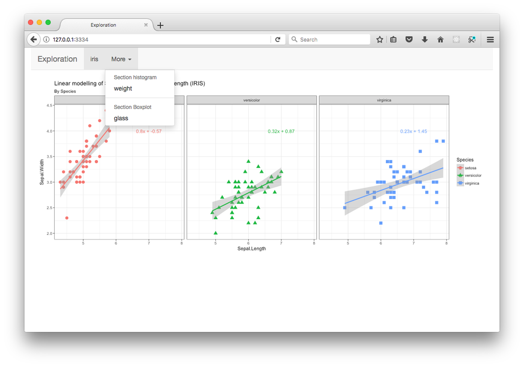

```r
# example
navbarPage("App Title",
             tabPanel("Plot"),
             navbarMenu("More",
                        tabPanel("Summary"),
                        "----",
                        "Section header",
                        tabPanel("Table")
             )
  )
```

3. Changez une dernière fois de mise en page en utilisant un `verticalLayout()`. Ce style de mise en page se retrouve souvent dans les sites internet pour mobiles.

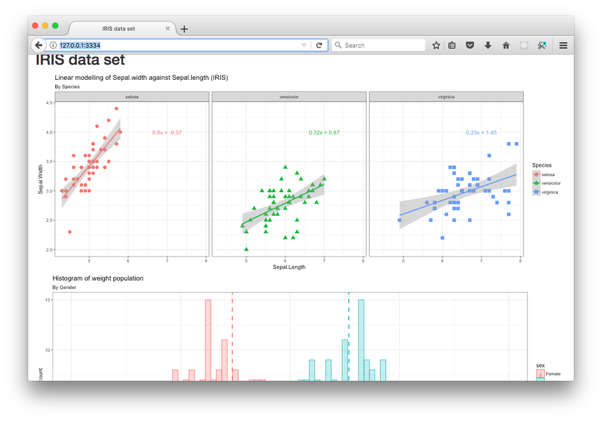

4. *[facultatif]* Continuez d’explorer les mises en page possible à travers Shiny, notamment les différences entre `fixedPage()` et `fluidPage()`, `flowLayout()` et `splitLayout()`, etc.

### Exercice 4 : (Your Shiny WebApp)

Imaginez vous-même une web application à partir de données que vous avez déjà analysées.

*À défaut, prendre le graphique de l’exercice 4 du TP-1 et rendez son exploration dynamique grâce à une nouvelle web application.*

### Exercice 5 : (Shiny dashboard)

Prenez le temps de visiter le site de [Shiny-dashboard](https://rstudio.github.io/shinydashboard/index.html) qui vous permettra de pousser vos développements de WebApps encore plus loin, et de créer en quelques lignes des tableaux de bords interactifs présentables en entreprise.